# 病历本

Yiyi

2021-08-05

# 1

```r
 rm(list = ls())
Sys.setlocale("LC_TIME", "English")
```

```
## [1] "English_United States.1252"
```

## 1.1 Packages

lag 是2:13 代表1:12. newdata里的1代表的是原数据. 首先把2:13 存储起来, 用paste0(2:13,加上”$“)用来匹配以2:13数字结尾的列?

```r
select(x,starts_with("s")) or select(df,end_with("string")) 句法 等同于df%>%select(matches("$"))
```

这两种做法都和之前是完全相等. 都只针对**列**操作,对表格内容无关. 在此只保留

```r
select(df,end_with("s"))
```

后续可以查看git 完全匹配字段的两种算法 commit

## 1.2 Lag and VAT

```r
old13<-c(2:13)
for (i in 1:12) {

  assign(paste0("lag",i),select(newdata,ends_with(paste0(old13[i]))))

}
lag1 <- lag1 %>% select(-contains("12"))
lag2 <- lag2 %>% select(-contains("13"))
VAT1 <- as.numeric(newdata$`time1` == "2008-12-01")
VAT2 <- as.numeric(newdata$`time1` == "2010-01-01")
VAT3 <- as.numeric(newdata$`time1` == "2011-01-01")
Recession <- as.numeric(newdata$`time1` >= "2008-04-01" & newdata$`time1`<= "2009-06-01")
```

## 1.3 Monthly dummies variable position

```r
monthname<-c("time_Apr","time_Aug", "time_Dec",  "time_Jan","time_Jul","time_Jun" ,"time_Mar","time_May","time_Nov","time_Oct","time_Sep")

for (i in 1:length(monthname)) {
  print(
 which(colnames(newdata)==monthname[i])
)
}
```

```
## [1] 2251
## [1] 2252
## [1] 2253
## [1] 2254
## [1] 2255
## [1] 2256
## [1] 2257
## [1] 2258
## [1] 2259
## [1] 2260
## [1] 2261
```

## 1.4 Create time_Apr etc.

```r
monthdummies<-newdata[,2251:2261]

  for (i in 1:11) {
  assign(colnames(monthdummies)[i],as.numeric(unlist(monthdummies[[i]])))
  }
```

## 1.5 CPI LDV variables position

```r
lag.list <- mget(paste0("lag", 1:12))


for (i in 1:12) {
  assign(paste0("lag",i),as.data.frame(lag.list[[i]]))
}

COPY <- as.data.frame(COPY)



# CPI-LAGS ----------------------------------------------------------------
cpi.list<-c(paste0("CPI ALL ITEMS",2:13))

for (i in 1:length(cpi.list)) {
  print(which(colnames(newdata)==cpi.list[i]))

}
```

```
## [1] 2
## [1] 3
## [1] 4
## [1] 5
## [1] 6
## [1] 7
## [1] 8
## [1] 9
## [1] 10
## [1] 11
## [1] 12
## [1] 13
```

```r
cpilag<-newdata[,2:13]
for (i in 1:12) {



  assign(paste0("CPI_lag",i),as.numeric(unlist(cpilag[,..i])))

}
```

## 1.6 Rgression

```r
# Regression Equation -----------------------------------------------------


reg.model <- lapply(1:173, function(x) lm(COPY[,x] ~ lag1[,x]+lag2[,x]+lag3[,x]+lag4[,x]+
                                            lag5[,x]+lag6[,x]+lag7[,x]+lag8[,x]+lag9[,x]+
                                            lag10[,x]+lag11[,x]+lag12[,x]+ time_Aug +
                                            time_Dec+ time_Apr+ time_Jan+time_Jul+time_Jun +
                                            time_Mar+time_May+time_Nov+time_Oct+time_Sep+VAT1+VAT2+VAT3+Recession+Trend)
)

for (i in 1:173) {
  names(reg.model[[i]]$coefficients)<-c('Constant','lag1','lag2',"lag3","lag4","lag5","lag6","lag7","lag8","lag9","lag10","lag11","lag12",
                                        "time_Aug" ,
                                        "time_Dec", "time_Feb", "time_Jan","time_Jul","time_Jun" ,"time_Mar",
                                        "time_May","time_Nov","time_Oct","time_Sep","VAT1","VAT2","VAT3","Recession","Trend")
}

regression <- lapply(1:122, function(x) lm(COPY[,x] ~ lag1[,x]+lag2[,x]+lag3[,x]+lag4[,x]+lag5[,x]+lag6[,x]+lag7[,x]+
                                             lag8[,x]+lag9[,x]+lag10[,x]+lag11[,x]+lag12[,x]+CPI_lag1+CPI_lag2+CPI_lag3+CPI_lag4+CPI_lag5+CPI_lag6+CPI_lag7+
                                             CPI_lag8+CPI_lag9+
                                             CPI_lag10+CPI_lag11+CPI_lag12+ time_Aug +
                                             time_Dec+ time_Apr+ time_Jan+time_Jul+time_Jun +time_Mar+
                                             time_May+time_Nov+time_Oct+time_Sep+VAT1+VAT2+VAT3+Recession+Trend)
)
for (i in 1:122) {
  names(regression[[i]]$coefficients)<-c('Constant','lag1','lag2',"lag3","lag4","lag5","lag6","lag7","lag8","lag9","lag10","lag11","lag12",
                                         "CPI_lag1","CPI_lag2","CPI_lag3","CPI_lag4","CPI_lag5","CPI_lag6","CPI_lag7","CPI_lag8","CPI_lag9",
                                         "CPI_lag10","CPI_lag11","CPI_lag12","time_Aug" ,
                                         "time_Dec", "time_Feb", "time_Jan","time_Jul","time_Jun" ,"time_Mar",
                                         "time_May","time_Nov","time_Oct","time_Sep","VAT1","VAT2","VAT3","Recession","Trend")
}
```

##前两列显著百分比

```r
percent <- function(x, digits = 2, format = "f", ...) {
  paste0(formatC(100 * x, format = format, digits = digits, ...), "%")
}
percent(1)
```

```
## [1] "100.00%"
```

## 1.7 Table 1 Summary table before stepwise 前两列

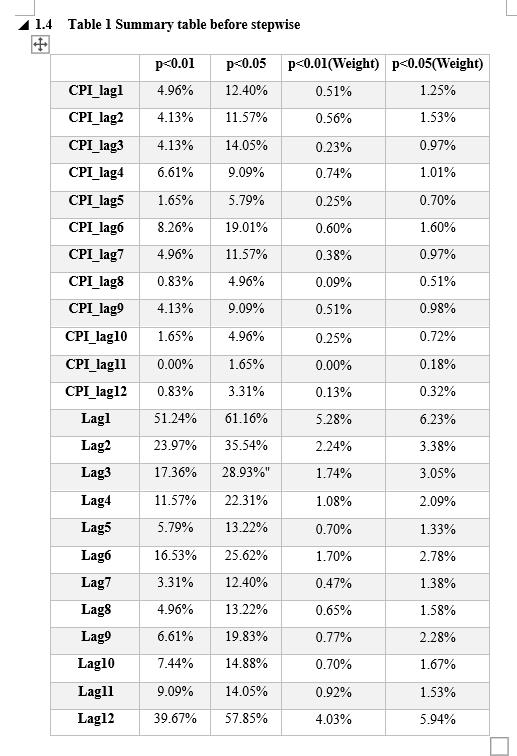

**论文第一表**

```r
a=list()
for (i in 1:12) {
  a[[i]] <- lapply(regression[2:122], function(x) summary(x)$coefficients[paste0("CPI_lag",i), 4])
  print(percent(length(which(a[[i]] < 0.05))/121))
  #print(a[[i]])
}
```

```
## [1] "12.40%"
## [1] "11.57%"
## [1] "14.05%"
## [1] "9.09%"
## [1] "5.79%"
## [1] "19.01%"
## [1] "11.57%"
## [1] "4.96%"
## [1] "9.09%"
## [1] "4.96%"
## [1] "1.65%"
## [1] "3.31%"
```

```r
for (i in 1:12) {
  a[[i]] <- lapply(regression[2:122], function(x) summary(x)$coefficients[paste0("CPI_lag",i), 4])

  print(percent(length(which(a[[i]] < 0.01))/121))
}
```

```
## [1] "4.96%"
## [1] "4.13%"
## [1] "4.13%"
## [1] "6.61%"
## [1] "1.65%"
## [1] "8.26%"
## [1] "4.96%"
## [1] "0.83%"
## [1] "4.13%"
## [1] "1.65%"
## [1] "0.00%"
## [1] "0.83%"
```

```r
for (i in 1:12) {
  a[[i]] <- lapply(regression[2:122], function(x) summary(x)$coefficients[paste0("lag",i), 4])
  print(percent(length(which(a[[i]] < 0.05))/121))
  #print(a[[i]])
}
```

```
## [1] "61.16%"
## [1] "35.54%"
## [1] "28.93%"
## [1] "22.31%"
## [1] "13.22%"
## [1] "25.62%"
## [1] "12.40%"
## [1] "13.22%"
## [1] "19.83%"
## [1] "14.88%"
## [1] "14.05%"
## [1] "57.85%"
```

```r
for (i in 1:12) {
  a[[i]] <- lapply(regression[2:122], function(x) summary(x)$coefficients[paste0("lag",i), 4])

  print(percent(length(which(a[[i]] < 0.01))/121))
}
```

```
## [1] "51.24%"
## [1] "23.97%"
## [1] "17.36%"
## [1] "11.57%"
## [1] "5.79%"
## [1] "16.53%"
## [1] "3.31%"
## [1] "4.96%"
## [1] "6.61%"
## [1] "7.44%"
## [1] "9.09%"
## [1] "39.67%"
```

## 1.8 后两列(Weight)

例如,01部门属于2-15.

```r
percent <- function(x, digits = 2, format = "f", ...) {
  paste0(formatC(100 * x, format = format, digits = digits, ...), "%")
}
# Weight ------------------------------------------------------------------
weight<- list(0.109,    0.042,  0.063,  0.115,  0.067,  0.022,  0.152,  0.023,  0.152,  0.019,  0.137,  0.099

)
Reduce("+",weight)
```

```
## [1] 1
```

用lapply 把regression 这个list 化成长数据框类型.(多行,5列:term,estimate,std,statitc, pvalue)

```r
tidy_mods <- lapply(regression, tidy)

for (i in 1:length(tidy_mods))
  tidy_mods[[i]]$mod <- names(tidy_mods[i])
a <- do.call(rbind.data.frame, tidy_mods)
str(a)
```

```
## tibble[,5] [5,002 x 5] (S3: tbl_df/tbl/data.frame)
##  $ term     : chr [1:5002] "Constant" "lag1" "lag2" "lag3" ...
##  $ estimate : num [1:5002] 0.3623 0.1157 -0.0351 0.0517 0.0445 ...
##  $ std.error: num [1:5002] 0.0754 0.0554 0.0552 0.055 0.0555 ...
##  $ statistic: num [1:5002] 4.802 2.089 -0.636 0.94 0.801 ...
##  $ p.value  : num [1:5002] 2.50e-06 3.75e-02 5.25e-01 3.48e-01 4.23e-01 ...
```

数数a里面有多少个vat1,就有多少个数据.which(a$term==“Trend”)[1]代表第一个trend在哪个位置. 每个部门的参数开始于constant,结束于Trend.

42:615行之间lag[n]且p<0.05的*weight[1]的length

01 Food and non-alcoholic beverages **2-15** 02 Alcoholic beverages, tobacco and narcotics **16-21** 03 Clothing and footwear **22-27** 04 Housing, water, electricity, gas and other fuels **28:40** 05 Furnishings, household equipment and routine household maintenance **41:53** 06 Health **54:61** 07 Transport **62:76** 08 Communication **77:79** 09 Recreation and culture **[80:101** 10 Education **102** 11 Restaurants and hotels **103：107** 12 Miscellaneous goods and services **108：122**

```r
dend<-c(2,16,22,28,41,54,62,77,80,102,103,108,122)#这只是每个部门开始的位置
for (i in 1:12) {
  assign(paste0("a",i),
         a[(which(a$term=="Constant")[dend[i]]):(which(a$term=="Trend")[dend[i+1]-1]),])
}
```

第一个constant的位置,到下一个Trend-1的位置. 第一个部门是2:15, 开始的标志是第二个constant的位置(dend[1]),结束于第15个Trend的位置(dend[2]-1的trend). **之所以不是直接开始于constant[dend[1]],结束于trend[dend[1]],是因为dend只是开始位置的集合(constant)而并不是结束的位置(trend).**

*如果constant[dend[1]]—trend[dend[1]],这代表第二个(dend[1]=2) constant的开始到第二个trend的结束.只是一个class.*

**如果constant[dend[1]]—trend[dend[2]],这代表第二个constant的开始到第16(dend[2]=16) 个trend的结束.我需要的是到第15个结束**

a1中lag1小于0.01的.a2中lag2小于0.01的.

**我想要的是a1中的lag1-12且小于0.01的个数×weight[1].**

这样就是[1]<-a1的lag1且小于0.01的*weight[1],[2]<-a2 lag1且小于0.01的个数*weight[2]

尝试先后循环 总共应该有多少个结果啊? a1[lag1:12] 12*12=144个

首先生成一个12*12的dataframe, 行是lag1-12, 列是a1:a12 十二个部门. 双循环,每个部门循环把lag1-lag12 循环一边存储在a_lag_0.01[,i]列里,然后再循环剩下11个部门.

### 1.8.1 a_lag.0.01

```r
a_lag.0.01<-data.frame( row.names =  paste0("lag",1:12),
                   matrix(nrow=12, ncol=12, ) )

colnames(a_lag.0.01)<-c(paste0("a",1:12))
i<-1#i=a,j=lag
while (i <=12) {
  for (j in 1:12) {
 a_lag.0.01 [j,i]  <-
  length( which((get(paste0("a",i)))$term==paste0("lag",j)&(get(paste0("a",i)))$p.value<0.01)
  )*weight[[i]]
  }
  i<-i+1
}
```

a8全都是0. 证实了一下确实. 有在0.05显著的,但是没有在0.01显著的.

[output not shown]

### 1.8.2 a_lag.0.05

```r
a_lag.0.05<-data.frame( row.names =  paste0("lag",1:12),
                   matrix(nrow=12, ncol=12, ) )

colnames(a_lag.0.05)<-c(paste0("a",1:12))
i<-1#i=a,j=lag
while (i <=12) {
  for (j in 1:12) {
 a_lag.0.05 [j,i]  <-
  length( which((get(paste0("a",i)))$term==paste0("lag",j)&(get(paste0("a",i)))$p.value<0.05)
  )*weight[[i]]
  }
  i<-i+1
}
```

### 1.8.3 a_cpi.0.01

```r
a_cpi.0.01<-data.frame( row.names =  paste0("CPI_lag",1:12),
                   matrix(nrow=12, ncol=12, ) )

colnames(a_cpi.0.01)<-c(paste0("a",1:12))
i<-1#i=a,j=lag
while (i <=12) {
  for (j in 1:12) {
 a_cpi.0.01 [j,i]  <-
  length( which((get(paste0("a",i)))$term==paste0("CPI_lag",j)&(get(paste0("a",i)))$p.value<0.01)
  )*weight[[i]]
  }
  i<-i+1
}
```

### 1.8.4 a_cpi.0.05

```r
a_cpi.0.05<-data.frame( row.names =  paste0("CPI_lag",1:12),
                   matrix(nrow=12, ncol=12, ) )

colnames(a_cpi.0.05)<-c(paste0("a",1:12))
i<-1#i=a,j=lag
while (i <=12) {
  for (j in 1:12) {
 a_cpi.0.05 [j,i]  <-
  length( which((get(paste0("a",i)))$term==paste0("CPI_lag",j)&(get(paste0("a",i)))$p.value<0.05)
  )*weight[[i]]
  }
  i<-i+1
}
```

$$\frac{\text{部门}1\text{显著个数}*weight\left[ 1 \right] +.....+}{121}$$
把a_cpi.0.05这四个表, 每行加起来/121 就是结果. 一行一个结果,每个表有12行,共4个表,**4×12=48**个结果. 首先生成存放结果的 24行×2列的dataframe

# 2 所有table1的结果都写入,这次要生成24*4的dataframe

```r
table1weight<-data.frame( matrix(nrow=24, ncol=4, )   )
colnames(table1weight)<-c("p<0.01","p<0.05","p<0.01(Weight)","p<0.05(Weight)")
rownames(table1weight)<-c(paste0("CPI_lag",1:12),paste0("lag",1:12))
```

写入结果 一个没有cpi的a dataframe,删除前41行

```r
nocpi<-a[-c(1:41),]
```

```r
for (i in 1:12) {#前两列
  table1weight[i,1]<-percent((length( which(nocpi$term==paste0("CPI_lag",i)&(nocpi$p.value<0.01))))/121)
   table1weight[i+12,1]<-percent((length( which(nocpi$term==paste0("lag",i)&(nocpi$p.value<0.01))))/121)
   table1weight[i,2]<-percent((length( which(nocpi$term==paste0("CPI_lag",i)&(nocpi$p.value<0.05))))/121)
      table1weight[i+12,2]<-percent((length( which(nocpi$term==paste0("lag",i)&(nocpi$p.value<0.05))))/121)
      #后两列
    table1weight[i,3]<-percent(sum(a_cpi.0.01[paste0("CPI_lag",i),])      /121)
    table1weight[i+12,3]<-percent(sum(a_lag.0.01[paste0("lag",i),])/121)
    table1weight[i,4]<-percent(sum(a_cpi.0.05[paste0("CPI_lag",i),])/121)
    table1weight[i+12,4]<-percent(sum(a_lag.0.05[paste0("lag",i),])/121)

}
```

flextable 写入word

```r
ft1<-flextable(table1weight %>% rownames_to_column("column name"))




save_as_docx("Summary table before stepwise" = ft1, path = "F:/R workspace/Modelling-UK-inflation-quarterly-/table1.docx")
```

# 3 Table 2 Stepwise Summary Table

## 3.1 stepwise function

```r
# function ----------------------------------------------------------------


# Automated model selection
# Author      : Joris Meys
# version     : 0.2
# date        : 12/01/09

#CHANGE LOG
# 0.2   : check for empty scopevar vector

# #CHANGE LOG -------------------------------------------------------------



# Function has.interaction checks whether x is part of a term in terms
# terms is a vector with names of terms from a model
has.interaction <- function(x,terms){
  out <- sapply(terms,function(i){
    sum(1-(strsplit(x,":")[[1]] %in% strsplit(i,":")[[1]]))==0
  })
  return(sum(out)>0)
}

# Function Model.select
# model is the lm object of the full model
# keep is a list of model terms to keep in the model at all times
# sig gives the significance for removal of a variable. Can be 0.1 too (see SPSS)
# verbose=T gives the F-tests, dropped var and resulting model after
model.select <- function(model,keep,sig=0.05,verbose=F){
  counter=1
  # check input
  if(!is(model,"lm")) stop(paste(deparse(substitute(model)),"is not an lm object\n"))
  # calculate scope for drop1 function
  terms <- attr(model$terms,"term.labels")
  if(missing(keep)){ # set scopevars to all terms
    scopevars <- terms
  } else{            # select the scopevars if keep is used
    index <- match(keep,terms)
    # check if all is specified correctly
    if(sum(is.na(index))>0){
      novar <- keep[is.na(index)]
      warning(paste(
        c(novar,"cannot be found in the model",
          "\nThese terms are ignored in the model selection."),
        collapse=" "))
      index <- as.vector(na.omit(index))
    }
    scopevars <- terms[-index]
  }

  # Backward model selection :

  while(T){
    # extract the test statistics from drop.
    test <- drop1(model, scope=scopevars,test="F")

    if(verbose){
      cat("-------------STEP ",counter,"-------------\n",
          "The drop statistics : \n")
      print(test)
    }

    pval <- test[,dim(test)[2]]

    names(pval) <- rownames(test)
    pval <- sort(pval,decreasing=T)

    if(sum(is.na(pval))>0) stop(paste("Model",
                                      deparse(substitute(model)),"is invalid. Check if all coefficients are estimated."))

    # check if all significant
    if(pval[1]<sig) break # stops the loop if all remaining vars are sign.

    # select var to drop
    i=1
    while(T){
      dropvar <- names(pval)[i]
      check.terms <- terms[-match(dropvar,terms)]
      x <- has.interaction(dropvar,check.terms)
      if(x){i=i+1;next} else {break}
    } # end while(T) drop var

    if(pval[i]<sig) break # stops the loop if var to remove is significant

    if(verbose){
      cat("\n--------\nTerm dropped in step",counter,":",dropvar,"\n--------\n\n")
    }

    #update terms, scopevars and model
    scopevars <- scopevars[-match(dropvar,scopevars)]
    terms <- terms[-match(dropvar,terms)]

    formul <- as.formula(paste(".~.-",dropvar))
    model <- update(model,formul)

    if(length(scopevars)==0) {
      warning("All variables are thrown out of the model.\n",
              "No model could be specified.")
      return()
    }
    counter=counter+1
  } # end while(T) main loop
  return(model)
}
```

# 4 **如果简化到0.01, 所有变量都在0.01显著了, 那0.05的列就全是0了.** 所以只有个 stepwsie function, 那就是到0.05.

```r
slr.total <- list()
keep.dummies <- c("time_Aug","time_Apr",
                  "time_Dec",  "time_Jan","time_Jul","time_Jun" ,"time_Mar","time_May","time_Nov","time_Oct","time_Sep",
                  "VAT1","VAT2","VAT3","Recession","Trend")
for (i in 2:122) {
  slr.total[[i]] <- model.select(regression[[i]], keep = keep.dummies, sig = 0.05, verbose = F)
}
```

**这个地方会卡一下** ## 在没换名字之前slr.total=122个,1和86是空集. 替换完名字就变成121了(1仍然空集.)

```r
#把1和86扔了
slr.total[sapply(slr.total, is.null)] <- NULL

#替换名称
search_for_these <- c("lag1[, x]","lag2[, x]","lag3[, x]","lag4[, x]","lag5[, x]","lag6[, x]","lag7[, x]","lag8[, x]","lag9[, x]","lag10[, x]","lag11[, x]","lag12[, x]")
 replace_with_these <- c("lag1","lag2","lag3","lag4","lag5","lag6","lag7","lag8","lag9","lag10","lag11","lag12")
 found<-list()
for (i in 1:length(slr.total)) {
  found[[i]] <- match(names(slr.total[[i]]$coefficients), search_for_these, nomatch = 0)
  names(slr.total[[i]]$coefficients)[names(slr.total[[i]]$coefficients) %in% search_for_these] <- replace_with_these[found[[i]]]
}
```

```r
#化成长数据类型
 tidy_stepwsie <- lapply(slr.total, tidy)
  stepwsie_a<- do.call(rbind.data.frame, tidy_stepwsie)
```

因为已经删减过cpi and 86, 所以stepwsie_a只剩下120个项目了.

```r
length(which(stepwsie_a$term=="VAT1"))
```

```
## [1] 120
```

**因为1和86是空集,所以每个部门开始的位置也变了. 86之前的变量-1,86之后的-2.**

```r
dend<-c(2,16,22,28,41,54,62,77,80,102,103,108,122)#这只是每个部门开始的位置
dend_stepwise<-c(dend[1:9]-1,dend[10:13]-2)

for (i in 1:12) {
  assign(paste0("stepwsie_a",i),
         stepwsie_a[(which(stepwsie_a$term=="(Intercept)")[dend_stepwise[i]]):(which(stepwsie_a$term=="Trend")[dend_stepwise[i+1]-1]),])
}
```

## 4.1 创建 Table 2 Stepwise Summary Table 存储结果

同样是24*4.

```r
stepwise_table_yearly<-data.frame( matrix(nrow=24, ncol=4, )   )
colnames(stepwise_table_yearly)<-c("p<0.01","p<0.05","p<0.01(Weight)","p<0.05(Weight)")
rownames(stepwise_table_yearly)<-c(paste0("CPI_lag",1:12),paste0("lag",1:12))
```

### 4.1.1 stepwise_lag_0.01_yearly

```r
stepwise_lag_0.01_yearly<-data.frame( row.names =  paste0("lag",1:12),
                   matrix(nrow=12, ncol=12, ) )

colnames(stepwise_lag_0.01_yearly)<-c(paste0("a",1:12))
i<-1#i=a,j=lag
while (i <=12) {
  for (j in 1:12) {
 stepwise_lag_0.01_yearly [j,i]  <-
  length( which((get(paste0("stepwsie_a",i)))$term==paste0("lag",j)&(get(paste0("stepwsie_a",i)))$p.value<0.01)
  )*weight[[i]]
  }
  i<-i+1
}
```

### 4.1.2 stepwise_lag_0.05_yearly

```r
stepwise_lag_0.05_yearly<-data.frame( row.names =  paste0("lag",1:12),
                   matrix(nrow=12, ncol=12, ) )

colnames(stepwise_lag_0.05_yearly)<-c(paste0("a",1:12))
i<-1#i=a,j=lag
while (i <=12) {
  for (j in 1:12) {
 stepwise_lag_0.05_yearly [j,i]  <-
  length( which((get(paste0("stepwsie_a",i)))$term==paste0("lag",j)&(get(paste0("stepwsie_a",i)))$p.value<0.05)
  )*weight[[i]]
  }
  i<-i+1
}
```

### 4.1.3 stepwise_cpi_0.01_yearly

```r
stepwise_cpi_0.01_yearly<-data.frame( row.names =  paste0("CPI_lag",1:12),
                   matrix(nrow=12, ncol=12, ) )

colnames(stepwise_cpi_0.01_yearly)<-c(paste0("a",1:12))
i<-1#i=a,j=lag
while (i <=12) {
  for (j in 1:12) {
 stepwise_cpi_0.01_yearly [j,i]  <-
  length( which((get(paste0("stepwsie_a",i)))$term==paste0("CPI_lag",j)&(get(paste0("stepwsie_a",i)))$p.value<0.01)
  )*weight[[i]]
  }
  i<-i+1
}
```

### 4.1.4 stepwise_cpi_0.05_yearly

```r
stepwise_cpi_0.05_yearly<-data.frame( row.names =  paste0("CPI_lag",1:12),
                   matrix(nrow=12, ncol=12, ) )

colnames(stepwise_cpi_0.05_yearly)<-c(paste0("a",1:12))
i<-1#i=a,j=lag
while (i <=12) {
  for (j in 1:12) {
 stepwise_cpi_0.05_yearly [j,i]  <-
  length( which((get(paste0("stepwsie_a",i)))$term==paste0("CPI_lag",j)&(get(paste0("stepwsie_a",i)))$p.value<0.05)
  )*weight[[i]]
  }
  i<-i+1
}
```

# 5 写入table2

```r
for (i in 1:12) {#前两列
  stepwise_table_yearly[i,1]<-percent((length( which(stepwsie_a$term==paste0("CPI_lag",i)&(stepwsie_a$p.value<0.01))))/121)
   stepwise_table_yearly[i+12,1]<-percent((length( which(stepwsie_a$term==paste0("lag",i)&(stepwsie_a$p.value<0.01))))/121)
   stepwise_table_yearly[i,2]<-percent((length( which(stepwsie_a$term==paste0("CPI_lag",i)&(stepwsie_a$p.value<0.05))))/121)
      stepwise_table_yearly[i+12,2]<-percent((length( which(stepwsie_a$term==paste0("lag",i)&(stepwsie_a$p.value<0.05))))/121)
      #后两列
    stepwise_table_yearly[i,3]<-percent(sum(stepwise_cpi_0.01_yearly[paste0("CPI_lag",i),])      /121)
    stepwise_table_yearly[i+12,3]<-percent(sum(stepwise_lag_0.01_yearly[paste0("lag",i),])/121)
    stepwise_table_yearly[i,4]<-percent(sum(stepwise_cpi_0.05_yearly[paste0("CPI_lag",i),])/121)
    stepwise_table_yearly[i+12,4]<-percent(sum(stepwise_lag_0.05_yearly[paste0("lag",i),])/121)

}
```

## 5.1 flextable 写入word

```r
ft1<-flextable(stepwise_table_yearly %>% rownames_to_column("column name"))




save_as_docx("1.5   Table 2 Stepwise Summary Table" = ft1, path = "F:/R workspace/Modelling-UK-inflation-quarterly-/table2.docx")
```

**验证是否和word的表相等**

```r
stargazer(slr.total[2:7],
          star.char = c("*"),
          star.cutoffs = c(0.01),
          notes = c(" * p<0.01; "),
          omit = c("time_Aug","time_Dec", "time_Apr", "time_Jan","time_Jul","time_Jun" ,"time_Mar","time_May","time_Nov","time_Oct","time_Sep",
                   "VAT1","VAT2","VAT3","Recession","Trend",'Constant'),

          dep.var.labels.include = FALSE,
          notes.append = FALSE,
          # order = c(1,2,3,4,5,6,7,8,9,10,11,12,13,14,15,16,17,18,19,20),
          report = "vc*",
          align = TRUE,
          header = FALSE,
          df = FALSE,
          digits = 2, single.row = TRUE,
          model.numbers = FALSE,
          column.labels = c(colnames(COPY[2:7])),
          summary = FALSE,
          out = "F:/R workspace/Modelling-UK-inflation-quarterly-/Table 2 Stepwise Summary Table/1-1.html",
          flip = FALSE,
          se = NULL,type = "text"
)
```

```
##
## ================================================================================================================
##                                                         Dependent variable:
##                     --------------------------------------------------------------------------------------------
##                     FOOD AND NON-ALCOHOLIC BEVERAGES  FOOD  BREAD and CEREALS  MEAT  FISH  MILK, CHEESE and EGGS
## ----------------------------------------------------------------------------------------------------------------
## lag1                             0.15*               -0.27*                   -0.32*              -0.33*
## lag12                             0.13
## lag8                                                 0.20*
## lag11                                                -0.11
## lag2                                                              0.21*       -0.20*               -0.14
## lag4                                                              -0.12
## CPI_lag1                                             0.63*        0.57*
## CPI_lag4                                              0.50        0.65*
## CPI_lag8                                                          0.44
## lag5                                                                                              -0.17*
## lag7                                                                           0.13                0.14*
## CPI_lag3                                                                       0.81                1.30
## CPI_lag5                                                                       0.80
## lag9                                                                                 0.16*         0.15*
## ----------------------------------------------------------------------------------------------------------------
## Observations                      324                 324          324         324    324           324
## R2                                0.25                0.32        0.24         0.22  0.11          0.22
## Adjusted R2                       0.21                0.27        0.19         0.17  0.06          0.16
## Residual Std. Error               0.62                0.70        0.76         1.29  0.83          2.15
## F Statistic                      5.74*               6.74*        4.52*       4.08*  2.21*         3.90*
## ================================================================================================================
## Note:                                                                                                  * p<0.01;
```

# 6 Table 3 Summary table before stepwise (Quarterly data)

```r
rm(list = ls())
Sys.setlocale("LC_TIME", "English")
```

```
## [1] "English_United States.1252"
```

```r
cpi <- read_excel("correct quarter cpi.xlsx")#108
cols.num <- c(colnames(cpi))#cols.列名
cpi[cols.num] <- sapply(cpi[cols.num],as.numeric)#把所有数据转成数字类型?

cpi <- as.data.table(cpi)
colnames(cpi) = gsub("&", "and", colnames(cpi))#把列名里&换成 and
COPY<-copy(cpi)
tracemem(COPY)==tracemem(cpi)
```

```
## [1] FALSE
```

```r
Data_A = as.data.table (cpi)
```

[output not shown]

```r
Varnames <- copy(names(Data_A))#
Data_A[, (names(Data_A)) := lapply(.SD, as.numeric)][,
                                                     rn := .I]
melted <- melt(Data_A, id.vars="rn")[,
                                     (paste0("lag_", 0:4)) := shift(value, 0:4, type="lag"),
                                     by=variable][,
                                                  value:=NULL][]
res <- dcast.data.table(melt(melted, id.vars=c("rn", "variable"), variable.name="lag"),
                        rn ~ variable + lag, sum)
res[, ncol(res), with=FALSE]
```

```
##      OTHER SERVICES (NEC)_lag_4
##   1:                         NA
##   2:                         NA
##   3:                         NA
##   4:                         NA
##   5:               0.0094975464
##  ---
## 108:              -0.0292461563
## 109:               0.0044922393
## 110:               0.0001439312
## 111:              -0.0026212275
## 112:               0.0039748113
```

```r
cpi <- cpi[, unlist(lapply(.SD, shift, n = 0:4), recursive = FALSE)]#lags generation
# quarterly  Dummies ---------------------------------------------------------


cpi$time <- seq.Date(from = as.Date("1992/01/01",format = "%Y/%m/%d"), by = "quarter", length.out = 112)
cpi$time <- format(cpi$time, format = "%b")

cpi <- fastDummies::dummy_cols(cpi, select_columns = "time", remove_most_frequent_dummy = TRUE,
)

cpi$time1 <- seq.Date(from = as.Date("1992/01/01",format = "%Y/%m/%d"), by = "quarter", length.out = 112)
# Trend,vat, recession ----------------------------------------------------

newdata<-copy(cpi)

newdata<-newdata[newdata$'time1' >= as.Date("1993-01-01")]
Trend <- seq_along(newdata$time1)

VAT1 <- as.numeric(newdata$`time1` == "2008-10-01")
VAT2 <- as.numeric(newdata$`time1` == "2010-01-01")
VAT3 <- as.numeric(newdata$`time1` == "2011-01-01")
Recession <- as.numeric(newdata$`time1` >= "2008-04-01" & newdata$`time1`<= "2009-06-01")
# Lag ---------------------------------------------------------------------

lag1 <- newdata %>%
  select(matches("(2)$"))
lag2 <- newdata %>%
  select(matches("(3)$"))
lag3 <- newdata %>%
  select(matches("(4)$"))
lag4 <- newdata %>%
  select(matches("(5)$"))

# MONTYHLY DUMMIES --------------------------------------------------------


quarter1 <- as.numeric(newdata$time_Jan)
quarter3 <- as.numeric(newdata$time_Jul)
quarter4 <- as.numeric(newdata$time_Oct)

COPY <- as.data.frame(COPY)
```

[output not shown]

```r
lag1 <- as.data.frame(lag1)
lag2 <- as.data.frame(lag2)
lag3 <- as.data.frame(lag3)
lag4 <- as.data.frame(lag4)

# CPI-LAGS ----------------------------------------------------------------


CPI_lag1 <- (newdata$"CPI ALL ITEMS2")
CPI_lag2 <- (newdata$"CPI ALL ITEMS3")
CPI_lag3 <- (newdata$"CPI ALL ITEMS4")
CPI_lag4 <- (newdata$"CPI ALL ITEMS5")
```

```r
# Copy删除前四行? --------------------------------------------------

COPY<-COPY[-1:-4,]
```

## 6.1 Regression

```r
regression <- lapply(1:122, function(x) lm(COPY[,x] ~ lag1[,x]+lag2[,x]+lag3[,x]+lag4[,x]+CPI_lag1+CPI_lag2+CPI_lag3+CPI_lag4+ quarter1+quarter3+quarter4+VAT1+VAT2+VAT3+Recession+Trend)
)
for (i in 1:122) {
  names(regression[[i]]$coefficients)<-c('Constant','lag1','lag2',"lag3","lag4",
                                         "CPI_lag1","CPI_lag2","CPI_lag3","CPI_lag4",
                                         "quarter1","quarter3","quarter4",
                                         "VAT1","VAT2","VAT3","Recession","Trend")
}
```

```r
regression <- lapply(1:122, function(x) lm(COPY[,x] ~ lag1[,x]+lag2[,x]+lag3[,x]+lag4[,x]+CPI_lag1+CPI_lag2+CPI_lag3+CPI_lag4+ quarter1+quarter3+quarter4+VAT1+VAT2+VAT3+Recession+Trend)
)
for (i in 1:122) {
  names(regression[[i]]$coefficients)<-c('Constant','lag1','lag2',"lag3","lag4",
                                         "CPI_lag1","CPI_lag2","CPI_lag3","CPI_lag4",
                                         "quarter1","quarter3","quarter4",
                                         "VAT1","VAT2","VAT3","Recession","Trend")
}
```

可以重复了 下面是重复yearly 部分

```r
percent <- function(x, digits = 2, format = "f", ...) {
  paste0(formatC(100 * x, format = format, digits = digits, ...), "%")
}
# Weight ------------------------------------------------------------------
weight<- list(0.109,    0.042,  0.063,  0.115,  0.067,  0.022,  0.152,  0.023,  0.152,  0.019,  0.137,  0.099

)
Reduce("+",weight)
```

```
## [1] 1
```

用lapply 把regression 这个list 化成长数据框类型.(多行,5列:term,estimate,std,statitc, pvalue)

```r
tidy_mods <- lapply(regression, tidy)

for (i in 1:length(tidy_mods))
  tidy_mods[[i]]$mod <- names(tidy_mods[i])
a <- do.call(rbind.data.frame, tidy_mods)
str(a)
```

```
## tibble[,5] [2,074 x 5] (S3: tbl_df/tbl/data.frame)
##  $ term     : chr [1:2074] "Constant" "lag1" "lag2" "lag3" ...
##  $ estimate : num [1:2074] 0.00796 0.32554 -0.0593 0.07128 0.24024 ...
##  $ std.error: num [1:2074] 0.00127 0.0885 0.09129 0.08849 0.08575 ...
##  $ statistic: num [1:2074] 6.278 3.678 -0.65 0.805 2.802 ...
##  $ p.value  : num [1:2074] 1.02e-08 3.89e-04 5.17e-01 4.23e-01 6.16e-03 ...
```

```r
dend<-c(2,16,22,28,41,54,62,77,80,102,103,108,122)#这只是每个部门开始的位置
for (i in 1:12) {
  assign(paste0("a",i),
         a[(which(a$term=="Constant")[dend[i]]):(which(a$term=="Trend")[dend[i+1]-1]),])
}
```

### 6.1.1 a_lag.0.01

```r
a_lag.0.01<-data.frame( row.names =  paste0("lag",1:12),
                   matrix(nrow=12, ncol=12, ) )

colnames(a_lag.0.01)<-c(paste0("a",1:12))
i<-1#i=a,j=lag
while (i <=12) {
  for (j in 1:12) {
 a_lag.0.01 [j,i]  <-
  length( which((get(paste0("a",i)))$term==paste0("lag",j)&(get(paste0("a",i)))$p.value<0.01)
  )*weight[[i]]
  }
  i<-i+1
}
```

### 6.1.2 a_lag.0.05

```r
a_lag.0.05<-data.frame( row.names =  paste0("lag",1:12),
                   matrix(nrow=12, ncol=12, ) )

colnames(a_lag.0.05)<-c(paste0("a",1:12))
i<-1#i=a,j=lag
while (i <=12) {
  for (j in 1:12) {
 a_lag.0.05 [j,i]  <-
  length( which((get(paste0("a",i)))$term==paste0("lag",j)&(get(paste0("a",i)))$p.value<0.05)
  )*weight[[i]]
  }
  i<-i+1
}
```

### 6.1.3 a_cpi.0.01

```r
a_cpi.0.01<-data.frame( row.names =  paste0("CPI_lag",1:12),
                   matrix(nrow=12, ncol=12, ) )

colnames(a_cpi.0.01)<-c(paste0("a",1:12))
i<-1#i=a,j=lag
while (i <=12) {
  for (j in 1:12) {
 a_cpi.0.01 [j,i]  <-
  length( which((get(paste0("a",i)))$term==paste0("CPI_lag",j)&(get(paste0("a",i)))$p.value<0.01)
  )*weight[[i]]
  }
  i<-i+1
}
```

### 6.1.4 a_cpi.0.05

```r
a_cpi.0.05<-data.frame( row.names =  paste0("CPI_lag",1:12),
                   matrix(nrow=12, ncol=12, ) )

colnames(a_cpi.0.05)<-c(paste0("a",1:12))
i<-1#i=a,j=lag
while (i <=12) {
  for (j in 1:12) {
 a_cpi.0.05 [j,i]  <-
  length( which((get(paste0("a",i)))$term==paste0("CPI_lag",j)&(get(paste0("a",i)))$p.value<0.05)
  )*weight[[i]]
  }
  i<-i+1
}
```

# 7 table3写入,这次要生成8*4的dataframe

```r
table3Quarterlydata<-data.frame( matrix(nrow=8, ncol=4, )   )
colnames(table3Quarterlydata)<-c("p<0.01","p<0.05","p<0.01(Weight)","p<0.05(Weight)")
rownames(table3Quarterlydata)<-c(paste0("CPI_lag",1:4),paste0("lag",1:4))
```

写入结果 一个没有cpi的a dataframe,删除前41行

```r
nocpi<-a[-c(1:41),]
```

```r
for (i in 1:4) {#前两列
  table3Quarterlydata[i,1]<-percent((length( which(nocpi$term==paste0("CPI_lag",i)&(nocpi$p.value<0.01))))/121)
   table3Quarterlydata[i+4,1]<-percent((length( which(nocpi$term==paste0("lag",i)&(nocpi$p.value<0.01))))/121)
   table3Quarterlydata[i,2]<-percent((length( which (nocpi$term==paste0("CPI_lag",i)&(nocpi$p.value<0.05))))/121)
      table3Quarterlydata[i+4,2]<-percent((length( which(nocpi$term==paste0("lag",i)&(nocpi$p.value<0.05))))/121)
      #后两列
    table3Quarterlydata[i,3]<-percent(sum(a_cpi.0.01[paste0("CPI_lag",i),])      /121)
    table3Quarterlydata[i+4,3]<-percent(sum(a_lag.0.01[paste0("lag",i),])/121)
    table3Quarterlydata[i,4]<-percent(sum(a_cpi.0.05[paste0("CPI_lag",i),])/121)
    table3Quarterlydata[i+4,4]<-percent(sum(a_lag.0.05[paste0("lag",i),])/121)

}
```

flextable 写入word

```r
ft1<-flextable(table3Quarterlydata %>% rownames_to_column("column name"))




save_as_docx("Summary table before stepwise (Quarterly data)" = ft1, path = "F:/R workspace/Modelling-UK-inflation-quarterly-/table3.docx")
```

# 8 quarterly stepwise

## 8.1 stepwise function

```r
slr.total <- list()
keep.dummies <- c("quarter1","quarter3","quarter4",
                  "VAT1","VAT2","VAT3","Recession","Trend")
for (i in 2:122) {
  slr.total[[i]] <- model.select(regression[[i]], keep = keep.dummies, sig = 0.05, verbose = F)
}
```

[output not shown]

## 8.2 slr.total所有变量都不显著的部门

```r
names(slr.total) <- 1:length(slr.total)
class_with_no_significant <- slr.total[which(sapply(slr.total, is.null))]
```

$`1`$`10`$`35`$`40`$`55`$`57`$`58`$`64`$`69`$`74`$`79`$`86`$`100`$`103`$`114`$`120`$`121`